© Bản quyền thuộc về Quantopian Inc.  
© Bản quyền sửa đổi thuộc về AI Cafe¹  
Giấy phép [Creative Commons Attribution 4.0](https://creativecommons.org/licenses/by/4.0/legalcode).  
[Khuyến cáo](https://aicafe.one/khuyen-cao/)

# p-Hacking và Thiên lệch so sánh nhiều

By Delaney Mackenzie and Maxwell Margenot

Edited by AI Cafe¹

Thiên lệch so sánh nhiều là một vấn đề phổ biến trong thống kê, khoa học dữ liệu, và nói chung là trong dự đoán. Giải thích ngắn gọn là càng chạy nhiều bài kiểm tra, bạn càng có khả năng nhận được một kết quả mà bạn mong muốn/hy vọng. Nếu bạn bỏ qua vô số bài kiểm tra thất bại, bạn đang tự đặt mình vào tình huống thất bại bằng cách hiểu sai về những gì đang xảy ra trong dữ liệu của bạn.

Một ví dụ đặc biệt phổ biến của vấn đề này là khi tìm kiếm các mối quan hệ trong các tập dữ liệu lớn bao gồm nhiều chuỗi độc lập hoặc biến. Trong trường hợp này, bạn thực hiện một bài kiểm tra mỗi khi bạn đánh giá xem có mối quan hệ nào giữa một tập hợp các biến hay không.

## Thống kê chỉ đơn giản làm rõ vấn đề

Hầu hết mọi người cũng bị rơi vào thiên lệch so sánh nhiều trong cuộc sống thực. Bất kỳ khi nào bạn đưa ra quyết định, bạn thực sự đang thực hiện một hành động dựa trên một giả thuyết. Giả thuyết đó thường được kiểm tra. Bạn có thể vô tình thực hiện nhiều bài kiểm tra trong cuộc sống hàng ngày của mình.

Một ví dụ có thể là quyết định loại thuốc nào giúp chữa cảm lạnh mà bạn đang mắc phải. Nhiều người sẽ uống nhiều loại thuốc cùng một lúc để cố gắng loại bỏ các triệu chứng. Bạn có thể nghĩ rằng một loại thuốc nhất định đã có tác dụng, khi thực tế không có loại nào hiệu quả và cảm lạnh chỉ đơn giản là bắt đầu cải thiện vào một thời điểm nào đó.

Điểm mấu chốt ở đây là vấn đề này không xuất phát từ việc kiểm tra thống kê và giá trị p. Thay vào đó, những kỹ thuật này cung cấp cho chúng ta nhiều thông tin hơn về vấn đề và khi nào nó có thể xảy ra.

```python
import numpy as np
import pandas as pd
import scipy.stats as stats
import matplotlib.pyplot as plt
```

## Hệ số tương quan hạng Spearman

Tham khảo bài giảng trước về Hệ số tương quan hạng Spearman để có thông tin đầy đủ hơn, nhưng đây là một tóm tắt rất ngắn gọn về Hệ số tương quan hạng Spearman.

Đây là một biến thể của hệ số tương quan, xem xét đến thứ hạng của dữ liệu. Điều này có thể giúp xử lý các phân phối bất thường hoặc các giá trị ngoại lai có thể làm rối loạn các phép đo khác. Bài kiểm tra cũng trả về một giá trị p-value, điều này rất quan trọng ở đây.

```python
X = pd.Series(np.random.normal(0, 1, 100))
Y = X

r_s = stats.spearmanr(Y, X)
print('Spearman Rank Coefficient:', r_s[0])
print('p-value:', r_s[1])
```

```
Spearman Rank Coefficient: 0.9999999999999999
p-value: 0.0
```

Nếu thêm một chút nhiễu, hệ số của chúng ta sẽ giảm.

```python
X = pd.Series(np.random.normal(0, 1, 100))
Y = X + np.random.normal(0, 1, 100)

r_s = stats.spearmanr(Y, X)
print('Spearman Rank Coefficient:', r_s[0])
print('p-value:', r_s[1])
```

```
Spearman Rank Coefficient: 0.6601980198019801
p-value: 7.906703904936615e-14
```

## Tóm tắt về p-value

Để biết thêm thông tin về p-value, xem bài Kiểm định giả thuyết. Điều quan trọng cần nhớ là p-value được sử dụng để kiểm tra giả thuyết dựa trên một số dữ liệu. Ở đây, chúng ta đang kiểm tra giả thuyết rằng có một mối quan hệ tồn tại giữa hai chuỗi dữ liệu dựa trên giá trị của các chuỗi đó.

### QUAN TRỌNG: p-value phải được coi như là giá trị nhị phân

Một sai lầm phổ biến là p-value được coi là có mức độ ý nghĩa hơn hoặc kém hơn. Đây là một thực hành tồi vì nó cho phép hiện tượng được gọi là [p-hacking](https://en.wikipedia.org/wiki/Data_dredging) và sẽ dẫn đến nhiều kết quả dương tính giả hơn bạn mong đợi. Hệ quả là bạn sẽ có khả năng thuyết phục bản thân rằng có những mối quan hệ tồn tại trong dữ liệu của bạn.

Để coi p-value là nhị phân, một ngưỡng phải được thiết lập trước. Sau đó, p-value phải được so sánh với ngưỡng và được coi là có ý nghĩa/không có ý nghĩa. Ở đây, chúng tôi sẽ chỉ ra điều này.

### Ngưỡng là mức độ ý nghĩa của chúng ta

Chúng ta có thể gọi ngưỡng này là mức độ ý nghĩa của chúng ta vì một ngưỡng thấp hơn có nghĩa là các kết quả vượt qua nó có ý nghĩa với mức độ tin cậy cao hơn. Vì vậy, nếu bạn có ngưỡng là 0.05, thì ngay cả trên dữ liệu ngẫu nhiên, 5% các bài kiểm tra sẽ vượt qua dựa trên sự ngẫu nhiên. Ngưỡng 0.01 giảm điều này xuống còn 1%, đây là một bài kiểm tra nghiêm ngặt hơn. Do đó, chúng ta có thể có nhiều niềm tin hơn vào các kết quả của mình.

```python
# Setting a cutoff of 5% means that there is a 5% chance
# of us getting a significant p-value given no relationship
# in our data (false positive).
# NOTE: This is only true if the test's assumptions have been
# satisfied and the test is therefore properly calibrated.
# All tests have different assumptions.
cutoff = 0.05

X = pd.Series(np.random.normal(0, 1, 100))
Y = X + np.random.normal(0, 1, 100)

r_s = stats.spearmanr(Y, X)
print('Spearman Rank Coefficient:', r_s[0])
if r_s[1] < cutoff:
    print('There is significant evidence of a relationship.')
else:
    print('There is not significant evidence of a relationship.')
```

```
Spearman Rank Coefficient: 0.7385538553855384
There is significant evidence of a relationship.
```

## Thí nghiệm - Chạy Nhiều Bài Kiểm Tra

Chúng ta sẽ bắt đầu bằng cách định nghĩa một khung dữ liệu.

```python
df = pd.DataFrame()
```

Bây giờ chúng ta sẽ làm đầy nó bằng cách thêm `N` chuỗi thời gian được tạo ngẫu nhiên có độ dài `T`.

```python
N = 20
T = 100

for i in range(N):
    X = np.random.normal(0, 1, T)
    X = pd.Series(X)
    name = 'X%s' % i
    df[name] = X
```

```python
df.head()
```

|  | X0 | X1 | X2 | X3 | X4 | X5 | X6 | X7 | X8 | X9 | X10 | X11 | X12 | X13 | X14 | X15 | X16 | X17 | X18 | X19 |
| --- | --- | --- | --- | --- | --- | --- | --- | --- | --- | --- | --- | --- | --- | --- | --- | --- | --- | --- | --- | --- |
| 0 | -0.409093 | 0.145137 | -1.557674 | 0.005421 | 0.593130 | 0.965287 | 0.301599 | 0.337557 | -1.768177 | 1.609656 | -1.464894 | 0.018295 | 0.879556 | -1.108281 | -0.307877 | 0.481820 | -0.258802 | -0.227150 | 1.326564 | -0.523331 |
| 1 | 0.260749 | -0.867946 | 0.962509 | -0.971805 | 0.812263 | -0.361873 | 0.033103 | 1.200634 | 1.017931 | -1.179807 | 1.209257 | 0.494147 | -1.829226 | 1.343561 | 0.166838 | 0.359160 | 1.541413 | -0.256432 | -1.435687 | -1.131597 |
| 2 | 2.449744 | 1.069539 | -1.489840 | 0.700125 | 0.865480 | 1.722094 | 0.138218 | -0.771660 | 1.477769 | -1.252347 | 0.738114 | 1.054119 | -0.500746 | -0.838624 | -0.157269 | -2.136406 | 0.615390 | 0.333291 | 0.381667 | -0.172201 |
| 3 | -1.407457 | 1.335426 | 2.127867 | 1.737728 | -1.139112 | 0.287821 | 0.871403 | 1.355442 | -0.302913 | 0.112381 | 0.104261 | -0.379918 | 1.188681 | -0.504959 | -0.563040 | -1.441456 | -0.992499 | 0.186707 | 1.054404 | 1.076539 |
| 4 | -0.410902 | -0.112139 | -1.280219 | -1.967527 | 0.618796 | -1.304224 | -0.819492 | 1.071199 | 0.937933 | -0.654699 | 1.117384 | 2.076997 | 0.179092 | -0.610271 | 0.580147 | -0.173543 | -1.161806 | -0.870064 | -0.222150 | 1.279905 |

Bây giờ chúng ta sẽ tiến hành kiểm tra tất cả các cặp trong dữ liệu của chúng ta để tìm các trường hợp mà giá trị p-value của chúng ta thấp hơn ngưỡng đã định là 5%.

```python
cutoff = 0.05

significant_pairs = []

for i in range(N):
    for j in range(i+1, N):
        Xi = df.iloc[:, i]
        Xj = df.iloc[:, j]

        results = stats.spearmanr(Xi, Xj)

        pvalue = results[1]

        if pvalue < cutoff:
            significant_pairs.append((i, j))
```

Trước khi chúng ta kiểm tra có bao nhiêu kết quả đáng kể, hãy thực hiện một số phép toán để kiểm tra xem chúng ta mong đợi bao nhiêu. Công thức cho số cặp dựa trên N chuỗi là

$$\frac{N(N-1)}{2}$$

Trong dữ liệu của chúng ta không có mối quan hệ nào vì tất cả đều được tạo ra ngẫu nhiên. Nếu bài kiểm tra của chúng ta được hiệu chỉnh đúng cách, chúng ta nên mong đợi tỷ lệ dương tính giả là 5% dựa trên ngưỡng 5% của chúng ta. Do đó, chúng ta nên mong đợi số cặp sau đây đạt được ý nghĩa dựa trên cơ hội ngẫu nhiên.

```python
(N * (N-1) / 2) * 0.05
```

```
9.5
```

Bây giờ hãy so sánh với số lượng mà chúng ta thực sự đã tìm thấy.

```python
len(significant_pairs)
```

```
12
```

Chúng ta không nên mong đợi các con số sẽ khớp nhau một cách nhất quán vì chúng ta chỉ thực hiện một thí nghiệm. Nếu chúng ta thực hiện nhiều thí nghiệm như vậy, chúng ta sẽ thấy sự hội tụ về những gì chúng ta mong đợi.

### Lặp lại Thí Nghiệm nhiều lần

```python
from IPython.display import clear_output

def do_experiment(N, T, cutoff=0.05):
    df = pd.DataFrame()

    # Make random data
    for i in range(N):
        X = np.random.normal(0, 1, T)
        X = pd.Series(X)
        name = 'X%s' % i
        df[name] = X

    significant_pairs = []

    # Look for relationships
    for i in range(N):
        for j in range(i+1, N):
            Xi = df.iloc[:, i]
            Xj = df.iloc[:, j]

            results = stats.spearmanr(Xi, Xj)

            pvalue = results[1]

            if pvalue < cutoff:
                significant_pairs.append((i, j))

    return significant_pairs


num_experiments = 100

results = np.zeros((num_experiments,))

for i in range(num_experiments):
    print(f'trial {i+1} of {num_experiments}')
    clear_output(wait=True)

    # Run a single experiment
    result = do_experiment(20, 100, cutoff=0.05)

    # Count how many pairs
    n = len(result)

    # Add to array
    results[i] = n

print('The average result is:', np.mean(results))
```

```
The average result is: 9.24
```

Càng nhiều thí nghiệm thì giá trị càng gần với mức lý thuyết.

## Hình dung những gì đang diễn ra

Điều đang xảy ra ở đây là các giá trị p (p-values) nên được phân phối đồng đều, vì không có tín hiệu nào trong dữ liệu cơ bản. Cơ bản, chúng không mang lại thông tin gì và sẽ có khả năng giống nhau để là 0.01 hoặc 0.99. Vì chúng xuất hiện ngẫu nhiên, bạn sẽ mong đợi một tỷ lệ nhất định của các giá trị p nằm dưới bất kỳ ngưỡng nào bạn chọn. Ngưỡng càng thấp, càng ít giá trị p vượt qua bài kiểm tra của bạn.

Hãy hình dung điều này bằng cách tạo một hàm đã được sửa đổi để trả về các giá trị p.

```python
def get_pvalues_from_experiment(N, T):
    df = pd.DataFrame()

    # Make random data
    for i in range(N):
        X = np.random.normal(0, 1, T)
        X = pd.Series(X)
        name = 'X%s' % i
        df[name] = X

    pvalues = []

    # Look for relationships
    for i in range(N):
        for j in range(i+1, N):
            Xi = df.iloc[:, i]
            Xj = df.iloc[:, j]

            results = stats.spearmanr(Xi, Xj)

            pvalue = results[1]

            pvalues.append(pvalue)

    return pvalues
```

Chúng ta sẽ thu thập một loạt các giá trị p. Như trong bất kỳ trường hợp nào, chúng ta sẽ muốn thu thập một số lượng khá lớn các giá trị p để bắt đầu có cái nhìn tổng quan về cách phân phối cơ bản trông như thế nào. Nếu chúng ta chỉ thu thập một vài giá trị, nó sẽ rất nhiễu như thế này:

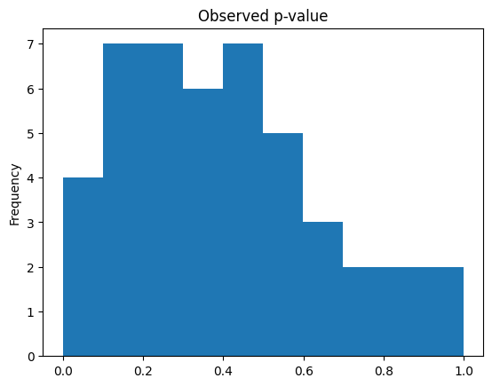

```python
pvalues = get_pvalues_from_experiment(10, 100)
plt.hist(pvalues)
plt.ylabel('Frequency')
plt.title('Observed p-value');
```

Hãy tăng tham số `N` của chúng ta lên để có cái nhìn rõ hơn. Hãy nhớ rằng số lượng p-value sẽ tăng theo tỷ lệ

$$\frac{N (N-1)}{2}$$

hay xấp xỉ bình phương của N. Do đó, chúng ta không cần phải tăng `N` quá nhiều.

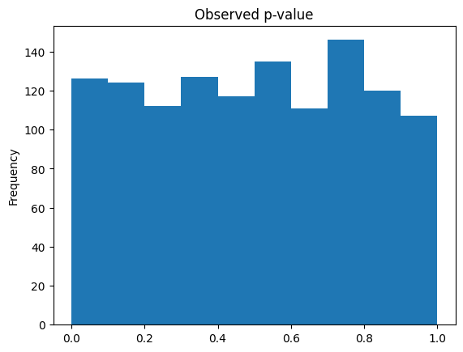

```python
pvalues = get_pvalues_from_experiment(50, 100)
plt.hist(pvalues)
plt.ylabel('Frequency')
plt.title('Observed p-value');
```

Như đã dự đoán, nó bắt đầu trở nên khá phẳng. Cuối cùng, chỉ để hình dung quá trình về ngưỡng cutoff, chúng ta sẽ vẽ hai đường tưởng tượng.

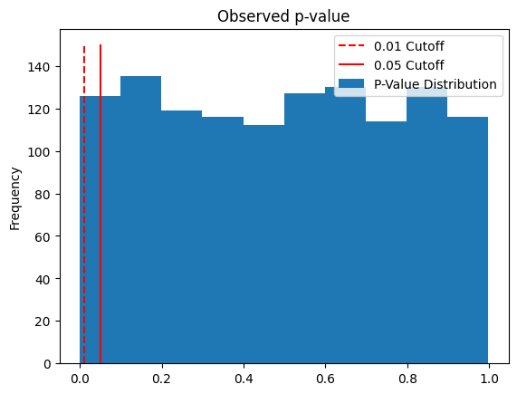

```python
pvalues = get_pvalues_from_experiment(50, 100)
plt.vlines(0.01, 0, 150, colors='r', linestyle='--', label='0.01 Cutoff')
plt.vlines(0.05, 0, 150, colors='r', label='0.05 Cutoff')
plt.hist(pvalues, label='P-Value Distribution')
plt.legend()
plt.ylabel('Frequency')
plt.title('Observed p-value');
```

Chúng ta có thể thấy rằng với một ngưỡng thấp hơn, chúng ta nên mong đợi ít kết quả dương tính giả hơn. Hãy kiểm tra điều đó với thí nghiệm ở trên của chúng ta.

```python
num_experiments = 100

results = np.zeros((num_experiments,))

for i in range(num_experiments):
    print(f'trial {i+1} of {num_experiments}')
    clear_output(wait=True)

    # Run a single experiment
    result = do_experiment(20, 100, cutoff=0.01)

    # Count how many pairs
    n = len(result)

    # Add to array
    results[i] = n

print('The average result is:', np.mean(results))
```

```
The average result is: 2.02
```

Và cuối cùng, hãy so sánh nó với những gì chúng ta đã mong đợi.

```python
(N * (N-1) / 2) * 0.01
```

```
1.9000000000000001
```

## Đánh đổi Giữa Độ Nhạy và Độ Đặc Hiệu

Giống như bất kỳ điều chỉnh nào của ngưỡng p-value, chúng ta có một sự đánh đổi. Ngưỡng thấp hơn sẽ giảm tỷ lệ dương tính giả, nhưng cũng làm giảm khả năng chúng ta phát hiện mối quan hệ thực sự (dương tính thật). Vì vậy, bạn không thể chỉ đơn giản là giảm ngưỡng của mình để giải quyết vấn đề này.

## Giảm Thiểu Thiên Kiến Do So Sánh Nhiều

Bạn không thể thực sự loại bỏ thiên kiến do so sánh nhiều, nhưng bạn có thể giảm thiểu ảnh hưởng của nó. Để làm điều đó, chúng ta có hai tùy chọn.

### Tùy chọn 1: Thực hiện ít thử nghiệm hơn.

Điều này thường là lựa chọn tốt nhất. Thay vì chỉ quét xung quanh hy vọng bạn tìm thấy một tín hiệu thú vị, hãy sử dụng kiến thức chuyên môn của bạn về hệ thống để phát triển một giả thuyết tốt và kiểm tra nó. Quy trình khám phá dữ liệu, đưa ra giả thuyết, sau đó thu thập thêm dữ liệu và kiểm tra giả thuyết trên dữ liệu mới được coi là tiêu chuẩn vàng trong nghiên cứu thống kê và khoa học. Điều quan trọng là bộ dữ liệu mà bạn phát triển giả thuyết không phải là bộ dữ liệu mà bạn kiểm tra. Bởi vì bạn đã tìm thấy hiệu ứng trong khi khám phá, bài kiểm tra sẽ qua và không thực sự cho bạn biết điều gì. Điều bạn muốn biết là hiệu ứng này có nhất quán không. Chuyển sang dữ liệu mới và kiểm tra ở đó không chỉ có nghĩa là bạn chỉ thực hiện một thử nghiệm, mà còn là một 'ước lượng không thiên lệch' về việc giả thuyết của bạn có đúng hay không.

### Tùy chọn 2: Các yếu tố điều chỉnh và Sửa đổi Bon Ferroni

#### CẢNH BÁO: Phần này có thể hơi kỹ thuật. Trừ khi bạn cảm thấy thoải mái với các mức ý nghĩa, chúng tôi khuyên bạn nên xem xét các ví dụ code trước và có thể đọc các bài viết liên kết trước khi hoàn toàn tiếp cận đoạn này.

Nếu bạn phải thực hiện nhiều thử nghiệm, hãy cố gắng điều chỉnh các p-value của bạn. Điều này có nghĩa là áp dụng một yếu tố điều chỉnh cho ngưỡng bạn mong muốn để có được ngưỡng thực tế được sử dụng khi xác định xem các p-value có ý nghĩa hay không. Yếu tố điều chỉnh bảo thủ và phổ biến nhất là Bon Ferroni.

### Ví dụ: Sửa đổi Bon Ferroni

Khái niệm đằng sau Bon Ferroni rất đơn giản. Nó chỉ ra rằng nếu chúng ta thực hiện $m$ thử nghiệm, và chúng ta có mức ý nghĩa/cutoff là $a$, thì chúng ta nên sử dụng $a/m$ làm cutoff mới của mình khi xác định ý nghĩa. Toán học diễn ra như sau.

Giả sử chúng ta thực hiện $m$ thử nghiệm. Chúng ta nên mong đợi thấy $ma$ kết quả dương giả dựa trên cơ hội ngẫu nhiên vượt qua cutoff của chúng ta. Nếu chúng ta thay vào đó sử dụng $a/m$ làm cutoff, thì chúng ta nên mong đợi thấy $ma/m = a$ thử nghiệm vượt qua cutoff của chúng ta. Do đó, chúng ta trở lại với tỷ lệ dương tính giả mong muốn là $a$.

Hãy thử áp dụng điều này vào thí nghiệm của chúng ta ở trên.

```python
num_experiments = 100

results = np.zeros((num_experiments,))

N = 20

T = 100

desired_level = 0.05

num_tests = N * (N - 1) / 2

new_cutoff = desired_level / num_tests

for i in range(num_experiments):

    print(f'trial {i+1} of {num_experiments}')
    clear_output(wait=True)

    # Run a single experiment
    result = do_experiment(20, 100, cutoff=new_cutoff)

    # Count how many pairs
    n = len(result)

    # Add to array
    results[i] = n

print('the average result is:', np.mean(results))
```

```
the average result is: 0.06
```

Như bạn thấy, số lượng kết quả có ý nghĩa của chúng ta hiện nay thấp hơn nhiều so với trung bình. Điều này là tốt vì dữ liệu ban đầu đã ngẫu nhiên.

### Những Điều Này Thường Quá Bảo Thủ

Vì Bon Ferroni rất nghiêm ngặt, bạn thường có thể bỏ qua những mối quan hệ thực sự. Có một ví dụ tốt trong bài viết sau:

https://en.wikipedia.org/wiki/Multiple_comparisons_problem

Về cơ bản, nó giả định rằng tất cả các bài kiểm tra bạn đang thực hiện là độc lập, và không tính đến bất kỳ cấu trúc nào trong dữ liệu của bạn. Bạn có thể có khả năng thiết kế một yếu tố điều chỉnh tinh vi hơn, nhưng điều này lại thêm một lớp phức tạp và do đó là một điểm thất bại cho nghiên cứu của bạn. Nói chung, bất cứ khi nào bạn nới lỏng sự nghiêm ngặt, bạn cần phải rất cẩn thận để không mắc sai lầm.

Vì sự quá mức của Bon Ferroni, thường thì việc chạy ít bài kiểm tra hơn là lựa chọn tốt hơn. Hoặc, nếu bạn phải chạy nhiều bài kiểm tra, hãy dành riêng nhiều bộ dữ liệu để các tín hiệu ứng viên của bạn có thể trải qua một vòng kiểm tra ngoài mẫu. Ví dụ, bạn có thể có quy trình như sau:

- Giả sử có 100.000 mối quan hệ có thể.
- Chạy một bài kiểm tra cho mỗi mối quan hệ có thể và chọn những mối quan hệ đã vượt qua bài kiểm tra.
- Với những ứng viên này, chạy một bài kiểm tra trên một bộ dữ liệu mới ngoài mẫu. Bởi vì bạn có ít ứng viên hơn, giờ đây bạn có thể áp dụng một phép điều chỉnh Bon Ferroni cho các giá trị p này, hoặc nếu cần, lặp lại một vòng kiểm tra ngoài mẫu khác.

## p-Hacking là gì?

p-hacking (hay còn gọi là khai thác p) là việc lạm dụng có chủ ý hoặc vô tình của độ thiên lệch so sánh đa dạng. Nó khá phổ biến, ngay cả trong tài liệu học thuật. Trang web thống kê nổi bật FiveThirtyEight có một hình minh họa tuyệt vời về điều này:

https://fivethirtyeight.com/features/science-isnt-broken/

Bài viết trên Wikipedia cũng có rất nhiều thông tin:

https://en.wikipedia.org/wiki/Data_dredging

Nói chung, khái niệm này khá đơn giản. Bằng cách thực hiện nhiều bài kiểm tra hoặc thí nghiệm và sau đó chỉ tập trung vào những cái đã thành công, bạn có thể trình bày các kết quả dương tính giả như là những kết quả thực sự. Hãy nhớ rằng điều này cũng áp dụng cho việc chạy nhiều mô hình khác nhau hoặc các loại thí nghiệm khác nhau trên các tập dữ liệu khác nhau. Hãy tưởng tượng rằng bạn dành một mùa hè để nghiên cứu một mô hình mới nhằm dự đoán giá ngô trong tương lai. Bạn thử nghiệm 50 mô hình khác nhau cho đến khi cuối cùng một mô hình thành công. Liệu đây có phải chỉ là may mắn không? Chắc chắn bạn sẽ muốn cẩn thận hơn trong việc xác nhận mô hình đó và thử nghiệm nó trên dữ liệu mới trước khi tin rằng nó hoạt động.

## Ghi chú cuối cùng

### Bạn không bao giờ có thể loại bỏ, chỉ có thể giảm thiểu rủi ro.

Nói chung, bạn không bao giờ có thể hoàn toàn loại bỏ thiên lệch so sánh nhiều lần, bạn chỉ có thể giảm thiểu rủi ro của các kết quả dương giả bằng các kỹ thuật mà chúng tôi đã mô tả ở trên. Cuối cùng, hầu hết các ý tưởng được thử nghiệm trong nghiên cứu đều không thành công, vì vậy bạn sẽ phải thử nghiệm nhiều giả thuyết khác nhau theo thời gian. Chỉ cần cố gắng cẩn thận và sử dụng lý trí về việc liệu có đủ bằng chứng cho thấy một giả thuyết là đúng hay bạn chỉ tình cờ gặp may ở lần thử này.

### Sử dụng kiểm tra ngoài mẫu

Như đã đề cập ở trên, kiểm tra ngoài mẫu là một trong những cách tốt nhất để giảm thiểu rủi ro của bạn. Bạn nên luôn luôn sử dụng nó, bất kể hoàn cảnh nào. Thường thì một trong những cách mà các kết quả dương giả lọt qua quy trình làm việc của bạn là thiếu một bài kiểm tra ngoài mẫu ở cuối.

## Tham khảo

- https://en.wikipedia.org/wiki/Multiple_comparisons_problem
- https://en.wikipedia.org/wiki/Sensitivity_and_specificity
- https://en.wikipedia.org/wiki/Bonferroni_correction
- https://fivethirtyeight.com/features/science-isnt-broken/

*Lưu ý: Tài liệu này mang tính chất chia sẻ kiến thức khoa học dữ liệu. Các mã chứng khoán xuất hiện trong tài liệu chỉ mang tính chất minh hoạ, không khuyến nghị đầu tư. Chúng tôi không chịu trách nhiệm trước mọi rủi ro nào do sử dụng tài liệu này.*